# Dia 1 Session 1: Introduccion a Rstudio y Rmarkdown

# Introduccion a Rstudio

Rstudio es un entorno integrado de dessarrolo o IDE (integrated development environment) para el lenguaje de programación R. El proposito de este software no es mas que facilitarle la vida a los programadores al integrar varios componentes que son comunmente usados durante el analisis de datos y desarrollo de software en R. Rstudio cuenta con varios componentes que se describiran a continuacion: la consola, un editor de textos, el entorno, el historial, y un visualizador de archivos y graficos.

[figure not shown]

La ventana de Rstudio por default

## La Consola

Al abrir Rstudio, podemos encontrar la consola de el lado izquierdo de la pantalla. La consola tiene dos funciones. Primero, es el lugar donde podemos escribir comandos para que la computadora los ejecute. Segundo, es el medio principal de comunicacion de salida de texto (output). Al empezar una sesion de R, la consola nos mostrara el texto de bienvenida seguido por el simbolo de entrada de texto “>”. Cuando ese simbolo esta presente, nos quiere decir que la computadora esta esperando nuestro comando.

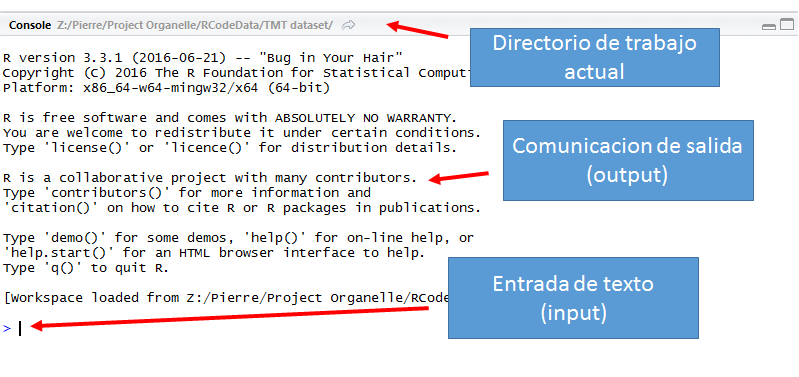

Algo importante que hay que tener en mente es que Rstudio nos indica nuestro directorio de trabajo actual **(working directory)** en la parte de arriba de la consola. Es importante tener en cuenta cual es nuestro directorio de trabajo ya que las operaciones de lectura y escritura de datos a discos se realizaran relativo a este directorio. Para cambiar nuestro directorio de trabajo podemos usar el comando setwd() o usando el menu “Session” -> “Set Working Directory”.

[figure not shown]

Vamos a tratar de empezar a usar R con operaciones basicas de aritmetica. Escribe las siguientes operaciones en la consola una linea a la vez.

```r
5+2
5*2
5^2
print("Hola mundo!")
```

Rstudio tiene un modo de autocompletar muy conveniente para escribir codigo. Trata de escribir en la consola las primeras tres letras de la palabra print y te aparecera un dialog con sugerencias de funciones.

Tip: Si deseas limpiar el texto que se encuentra en la consola puedes presionar Ctrl+L

## Editor de Textos

Una de las funciones mas improtantes de Rstudio es el editor de textos que tiene integrado. El editor de texto es donde podemos escribir nuestros scripts (i.e., lineas de codigo que ejecutan una serie de comandos deseasdos) antes de ejecutarlos en la consola.

Si es la primera vez que inicias una sesion de Rstudio, el editor de texto no aparecera en tu pantalla. Para mostrarlo puedes crear un archivo nuevo usando el menu File > New File > R Script. Trata de escribir (o copiar) el siguiente texto a el editor de textos:

```r
#Esto es un comentario
for( i in 1:10){
    print("Hola mundo!")
}
#print("Esto es un comentario y R lo ignorara.")
```

Podras darte cuenta que al igual que en este articulo, el texto tiene diferentes colores. Rstudio tiene la opcion de colorear cierto texto de tu codigo para hacerlo mas facil de leer. Palabras claves reservadas para R, por ejemplo los operadores ‘for’ y ‘in’ se muestran de un color. Texto que se interpreta como *strings* al estar dentro de comillas (" “) se muestra de otro color. Finalmente, los comentarios (i.e., porciones de tu codigo que no se ejecutan, pero sirven para anotar el codigo) se muestran de otro color. Mas adelante explicaremos para que sirven estas palabras claves y como comentar tu codigo.

Una vez que hemos escrito nuestro codigo, podemos ejecutarlo todo a la vez. Para hacer esto seleccionamos el codigo que deseamos ejecutar y presionames Ctrl+Enter o podemos dar click en el boton que dice “Run”. Al hacer esto el texto es copiado a la consola y se ejecutara. El output debera de ser similar a lo que aparece abajo:

```
## [1] "Hola mundo!"
## [1] "Hola mundo!"
## [1] "Hola mundo!"
## [1] "Hola mundo!"
## [1] "Hola mundo!"
## [1] "Hola mundo!"
## [1] "Hola mundo!"
## [1] "Hola mundo!"
## [1] "Hola mundo!"
## [1] "Hola mundo!"
```

Te daras cuenta que el comentario (texto despues de #) es ignorado. No debes de preocuparte si estos acaban entrando como parte de nuestro input en la consola.

TIP: Es importante que pongamos comentarios en nuestro codigo para poder entender facilmente tu codigo, en especial cuando alguien mas necesita leer tu codigo. Por ejemplo, tus colegas o instructores. Existen guias de estilo para comentar tu codigo que no tendremos tiempo para cubri, pero si te interesa puedes checar la guia de estilo que usa Google para R https://google.github.io/styleguide/Rguide.xml

## El Entorno

La ventana de entorno (workspace) muestra los **objetos** que se encuentra en la memoria durante nuestra sesion de R. La mayoria de los lenguajes de programacion modernos se manejan basados en objetos (object-oriented). Estos objetos son una representacion abstracta de datos y se asocian con un nombre que le damos nosotros. Mas adelante repasaremos los objetos basicos que son utilizados en R. Por ahora vamos a empezar creando objetos numericos en forma de escalares, vectores, y matrices.

Abre el script guardado en el archivo “Leccion1.R” y ejecutalo.

```r
x <- 5          #escalar
x
A <- c(1,2,3,4)     #vector
A
B <- matrix(c(1,2,3,4,5,6,7,8), nrow=4, ncol=2, byrow=TRUE) #matriz
B
```

El operador que tiene forma de flecha <- esta formado por un signo de ‘menor que’ < y un guion. La primera linea crea un objeto llamado ‘x’ en la memoria y asignarle el numero 5. Podras ver que el objeto aparece en la ventana de entorno junto con su valor (5). Lo mismo sucede con el objeto ‘A’. Finalmente, tenemos el objeto ‘B’ que es una matriz de 4 filas y 2 columnas. Rstudio tiene la funcion de mostrar algunos tipos de datos en forma de hoja de Excel, dandole click a el icono que aparece a la derecha de el objeto dentro de el entorno.

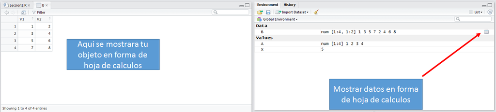

## El Historial

El historial guarda todos los comandos que se han ejecutado desde el inicio de la secion. Para ver el historial da click en “History” a lado de el “Workspace”. Esta opcion es muy conveniente si te gusta escribir el condigo directamente en la consola y despues quieres guardarlo. Para hacer esto puedes dar click en el icono de guardar o en el icono de “To Source” que copiara el codigo seleccionado hacia el editor de textos.

[figure not shown]